# Most Harmfull Events Across United States From 1950 To 2011

Araks Stepanyan

06/19/2017

## Synopsis

In this report we explore U.S. National Oceanic and Atmospheric Administration’s (NOAA) storm database. This database tracks characteristics of major storms and weather events in the United States, including when and where they occur, as well as estimates of any fatalities, injuries, and property damage. From these data, we found out, that Tornado is the most harmful type of event with respect to population health. We also saw that while Excessive Heat was the third most harmful event in 1991-2000, it became the second most harmful event type in 2001-2011. In terms of economic consequences, Flood is the most harmful type of event, followed by Hurricane/Typhoon and Tornado.

## Data Processing

Here is a description of the steps taken to download data, read data into R and preprocess it.  
1. Create a directory which will hold the NOAA Storm Database file  
2. Download data from the web  
3. Read data into R using read.csv. This may take several minutes (no need to unzip)

```r
# 1
if(!dir.exists("./NOAA_Storm_Database")){dir.create("./NOAA_Storm_Database")}

# 2
fileUrl <- "https://d396qusza40orc.cloudfront.net/repdata%2Fdata%2FStormData.csv.bz2"
if(!file.exists("./NOAA_STORM_DATABASE/storm_data.csv.bz2")) {download.file(fileUrl, destfile = "./NOAA_Storm_Database/storm_data.csv.bz2", method = "curl")}

# 3
storm_data <- read.csv("./NOAA_Storm_Database/storm_data.csv.bz2")
```

We can now look at the first few rows of the dataset (there are 902297 rows in the dataset). We also look at the column names.

```r
dim(storm_data)
```

```
## [1] 902297     37
```

```r
head(storm_data[,1:8])
```

```
##   STATE__           BGN_DATE BGN_TIME TIME_ZONE COUNTY COUNTYNAME STATE
## 1       1  4/18/1950 0:00:00     0130       CST     97     MOBILE    AL
## 2       1  4/18/1950 0:00:00     0145       CST      3    BALDWIN    AL
## 3       1  2/20/1951 0:00:00     1600       CST     57    FAYETTE    AL
## 4       1   6/8/1951 0:00:00     0900       CST     89    MADISON    AL
## 5       1 11/15/1951 0:00:00     1500       CST     43    CULLMAN    AL
## 6       1 11/15/1951 0:00:00     2000       CST     77 LAUDERDALE    AL
##    EVTYPE
## 1 TORNADO
## 2 TORNADO
## 3 TORNADO
## 4 TORNADO
## 5 TORNADO
## 6 TORNADO
```

```r
names(storm_data)
```

```
##  [1] "STATE__"    "BGN_DATE"   "BGN_TIME"   "TIME_ZONE"  "COUNTY"
##  [6] "COUNTYNAME" "STATE"      "EVTYPE"     "BGN_RANGE"  "BGN_AZI"
## [11] "BGN_LOCATI" "END_DATE"   "END_TIME"   "COUNTY_END" "COUNTYENDN"
## [16] "END_RANGE"  "END_AZI"    "END_LOCATI" "LENGTH"     "WIDTH"
## [21] "F"          "MAG"        "FATALITIES" "INJURIES"   "PROPDMG"
## [26] "PROPDMGEXP" "CROPDMG"    "CROPDMGEXP" "WFO"        "STATEOFFIC"
## [31] "ZONENAMES"  "LATITUDE"   "LONGITUDE"  "LATITUDE_E" "LONGITUDE_"
## [36] "REMARKS"    "REFNUM"
```

## Results

We want to answer two questions. Here is the first one.

### Across the United States, which types of events (as indicated in the 𝙴𝚅𝚃𝚈𝙿𝙴 variable) are most harmful with respect to population health?

Step_by_step description of analysis which is followed by the corresponding code.

1. For this part we only need 4 columns from the dataset (**BGN_DATE**, **EVTYPE**, **FATALITIES**, **INJURIES**). Let’s sumbset the data frame to have only these 4 columns (using **dplyr** package).
2. Using **lubridate** package convert the **BGN_DATE** column to **POSIXct**.
3. Add a new column to the data frame called **YEAR** to have only the years from the **BGN_DATE** column.
4. We know that there are fewer records in earlyer years so we will create a new column which we will call **INTERVAL_YEAR**. This new column divides **YEAR** column into several intervals to allow us observe the more recent years separately from the earlyer years.
5. Make two plots.
- **PANEL PLOT** of top 5 types of events per interval.
  1. Add two columns to our data_frame which count total number of event types and total fatalities and injuries in each interval. From these columns create a data frame with only 4 rows (one row for each interval totals) which we will later use to annotate our plot. We are going to compare every type of event in each interval against these interval totals.
  2. Create a new column called **PERCENT**. For each interval this column will have the percentages of the number of fatalities and injuries. From **PERCENT** we will create another column **PERCENT_CHAR** which is the character representation of **PERCENT** (with “%” added at the end of each number).
  3. Create a data frame called **health_df_top_5** which will have only the top 5 events for each interval.
- **SINGLE PLOT** of top 10 types of events that caused fatalities and injuries during 1950-2011.
  1. Create a data frame (**health_df_total**) which will have total number of fatalities and injuries per event type.
  2. Calculate total number of event types (1 number), as well as total number of fatalities and injuries (1 number). We will use these numbers to annotate our plot. And we will compare fatalities and injuries of each of the 10 event types to this total number of fatalities and injuries.
  3. In the same way as above, create **PERCENT** and **PERCENT_CHAR** columns to make our plot more informative.

```r
library(dplyr)
library(lubridate)
# 1
health_df <- storm_data %>% select(BGN_DATE, EVTYPE, FATALITIES, INJURIES)
dim(health_df)
```

```
## [1] 902297      4
```

```r
head(health_df, 3)
```

```
##            BGN_DATE  EVTYPE FATALITIES INJURIES
## 1 4/18/1950 0:00:00 TORNADO          0       15
## 2 4/18/1950 0:00:00 TORNADO          0        0
## 3 2/20/1951 0:00:00 TORNADO          0        2
```

```r
# 2
health_df$BGN_DATE <- mdy_hms(as.character(health_df$BGN_DATE))
dim(health_df)
```

```
## [1] 902297      4
```

```r
head(health_df, 3)
```

```
##     BGN_DATE  EVTYPE FATALITIES INJURIES
## 1 1950-04-18 TORNADO          0       15
## 2 1950-04-18 TORNADO          0        0
## 3 1951-02-20 TORNADO          0        2
```

```r
# 3
health_df <- health_df %>% mutate(YEAR = year(health_df$BGN_DATE))
dim(health_df)
```

```
## [1] 902297      5
```

```r
head(health_df, 3)
```

```
##     BGN_DATE  EVTYPE FATALITIES INJURIES YEAR
## 1 1950-04-18 TORNADO          0       15 1950
## 2 1950-04-18 TORNADO          0        0 1950
## 3 1951-02-20 TORNADO          0        2 1951
```

```r
# 4
health_df <- health_df %>%
        mutate(INTERVAL_YEAR = cut(YEAR,
                                   breaks = c(1950, 1970, 1990, 2000, 2011),
                                   labels = c("1950-1970", "1971-1990", "1991-2000", "2001-2011"),
                                   include.lowest = TRUE))
dim(health_df)
```

```
## [1] 902297      6
```

```r
head(health_df, 3)
```

```
##     BGN_DATE  EVTYPE FATALITIES INJURIES YEAR INTERVAL_YEAR
## 1 1950-04-18 TORNADO          0       15 1950     1950-1970
## 2 1950-04-18 TORNADO          0        0 1950     1950-1970
## 3 1951-02-20 TORNADO          0        2 1951     1950-1970
```

```r
# 5

# Panel Plot

# a
health_df_interval_event <- health_df %>%
        group_by(INTERVAL_YEAR, EVTYPE) %>%
        summarize(FATALITY_INJURY = sum(FATALITIES, INJURIES))

health_df_interval_event_count <- health_df_interval_event %>%
        group_by(INTERVAL_YEAR) %>%
        mutate(count_event_type = length(EVTYPE),
               count_fatal_inj = sum(FATALITY_INJURY))
dim(health_df_interval_event_count)
```

```
## [1] 1105    5
```

```r
head(health_df_interval_event_count, 3)
```

```
## # A tibble: 3 x 5
## # Groups:   INTERVAL_YEAR [1]
##   INTERVAL_YEAR    EVTYPE FATALITY_INJURY count_event_type count_fatal_inj
##          <fctr>    <fctr>           <dbl>            <int>           <dbl>
## 1     1950-1970      HAIL               0                3           35524
## 2     1950-1970   TORNADO           35524                3           35524
## 3     1950-1970 TSTM WIND               0                3           35524
```

```r
counts_df <- health_df_interval_event_count %>%
        select(INTERVAL_YEAR, count_event_type, count_fatal_inj) %>%
        group_by(INTERVAL_YEAR) %>%
        filter(row_number() <= 1)
dim(counts_df)
```

```
## [1] 4 3
```

```r
counts_df
```

```
## # A tibble: 4 x 3
## # Groups:   INTERVAL_YEAR [4]
##   INTERVAL_YEAR count_event_type count_fatal_inj
##          <fctr>            <int>           <dbl>
## 1     1950-1970                3           35524
## 2     1971-1990                3           37283
## 3     1991-2000              930           45019
## 4     2001-2011              169           37847
```

```r
# b
health_df_interval_event_count_percentage <- health_df_interval_event_count %>%
        group_by(INTERVAL_YEAR, EVTYPE) %>%
        mutate(PERCENT = FATALITY_INJURY * 100 / count_fatal_inj) %>%
        mutate(PERCENT_CHAR = paste(as.character(round(PERCENT, digits = 2)), "%"))
dim(health_df_interval_event_count_percentage)
```

```
## [1] 1105    7
```

```r
head(health_df_interval_event_count_percentage, 3)
```

```
## # A tibble: 3 x 7
## # Groups:   INTERVAL_YEAR, EVTYPE [3]
##   INTERVAL_YEAR    EVTYPE FATALITY_INJURY count_event_type count_fatal_inj
##          <fctr>    <fctr>           <dbl>            <int>           <dbl>
## 1     1950-1970      HAIL               0                3           35524
## 2     1950-1970   TORNADO           35524                3           35524
## 3     1950-1970 TSTM WIND               0                3           35524
## # ... with 2 more variables: PERCENT <dbl>, PERCENT_CHAR <chr>
```

```r
# c
health_df_top_5 <- health_df_interval_event_count_percentage %>%
        group_by(INTERVAL_YEAR) %>%
        arrange(INTERVAL_YEAR, desc(FATALITY_INJURY)) %>%
        top_n(n = 5, wt = FATALITY_INJURY)
dim(health_df_top_5)
```

```
## [1] 16  7
```

```r
head(health_df_top_5)
```

```
## # A tibble: 6 x 7
## # Groups:   INTERVAL_YEAR [2]
##   INTERVAL_YEAR    EVTYPE FATALITY_INJURY count_event_type count_fatal_inj
##          <fctr>    <fctr>           <dbl>            <int>           <dbl>
## 1     1950-1970   TORNADO           35524                3           35524
## 2     1950-1970      HAIL               0                3           35524
## 3     1950-1970 TSTM WIND               0                3           35524
## 4     1971-1990   TORNADO           34259                3           37283
## 5     1971-1990 TSTM WIND            2735                3           37283
## 6     1971-1990      HAIL             289                3           37283
## # ... with 2 more variables: PERCENT <dbl>, PERCENT_CHAR <chr>
```

We have everything we need to make the panel plot.

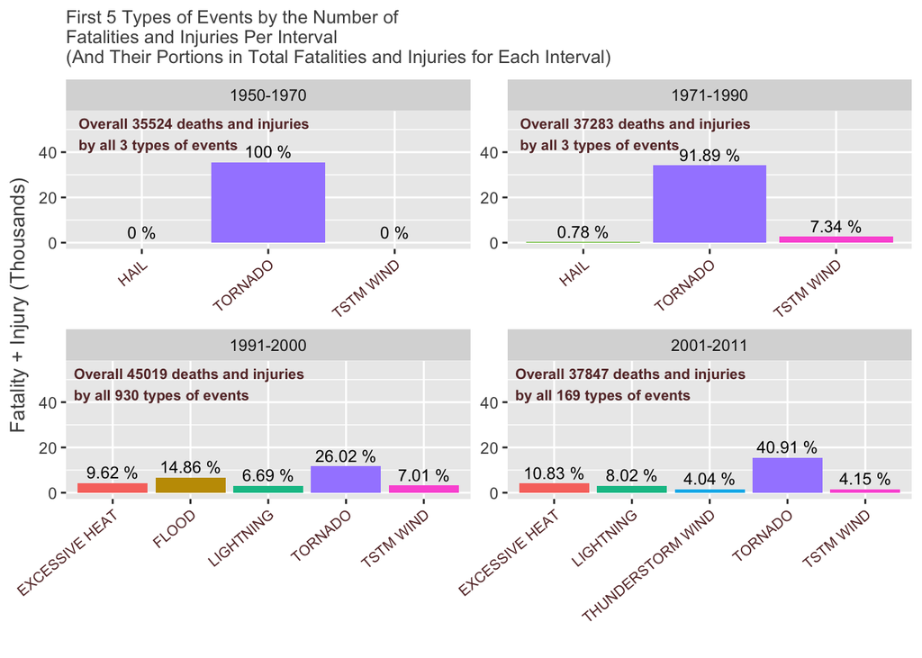

```r
# The plot
library(ggplot2)

div = 1000
ggplot(health_df_top_5, aes(x = EVTYPE, y = FATALITY_INJURY/div, fill = EVTYPE))+
        facet_wrap(~INTERVAL_YEAR, nrow = 2, scales = "free") +
        geom_bar(stat = "Identity") +
        geom_text(aes(label = PERCENT_CHAR), vjust = -0.4, size = 3.2) +
        labs(title = "First 5 Types of Events by the Number of \nFatalities and Injuries Per Interval\n(And Their Portions in Total Fatalities and Injuries for Each Interval)",
             x = "", y = "Fatality + Injury (Thousands)") +
        theme(legend.position = "none") +
        theme(axis.text.x = element_text(angle = 40, hjust = 1, vjust = 1, size = 8, color = rgb(0.4,0.2,0.2))) +
        theme(axis.title.y = element_text(color = rgb(0.3,0.3,0.3))) +
        theme(plot.title = element_text(color = rgb(0.3,0.3,0.3), size = 10)) +
        scale_y_continuous(limits = c(min(health_df_top_5$FATALITY_INJURY),
                                      max(health_df_top_5$FATALITY_INJURY)+20000)/div) +
        annotate("text", x = 0.5, y = 55, size = 2.8, hjust = "inward", vjust = "inward",
                 color = rgb(0.4,0.2,0.2), fontface = 2,
                 label = paste("Overall", as.character(counts_df$count_fatal_inj),
                               "deaths and injuries\nby all",
                               as.character(counts_df$count_event_type),
                               "types of events"))
```

From the plot above we clearly see that in all 4 interval the most harmful event type is Tornado. The second harmful event is different from interval to interval. First of all, we notice that in 1950-1970 and 1971-1990 only three types of events were recorded (and that is why the sum of percentages is 100%).  
**1950-1970** - Tornado is the only winner in terms of human health harms.  
**1971-1990** - Tornado is the first harmful event type. Second harmful event type is Tstm Wind (which is Marine Thunderstorm Wind, by the way, as we can see in [Storm Data Documentation](https://d396qusza40orc.cloudfront.net/repdata%2Fpeer2_doc%2Fpd01016005curr.pdf)). And Hail is the third harmful event type with respect to population health.

In 1991-2000 and 2001-2011 there are many types of events recorded (that is why the sum of percentages is not equal to 100%, as only 5 event types are shown on the plot).

**1991-2000** - Tornado is the first harmful event type, Flood is the second. Then come Excessive Heat, Tstm Wind and Lightning.  
**2001-2011** - Tornado is again the first harmful event type, but this time Excessive Heat goes up one level from the previous decade and is now the second harmful event (global warming?). And then come Lightning, Tstm Wind, and Thunderstorm Wind.

```r
# Single Plot
library(dplyr)
library(ggplot2)

# a
health_df_total <- health_df %>%
        group_by(EVTYPE) %>%
        summarize(FATALITY_INJURY = sum(FATALITIES, INJURIES)) %>%
        arrange(desc(FATALITY_INJURY))

# b
count_event_types <- nrow(health_df_total)
count_fatal_injur <- sum(health_df_total$FATALITY_INJURY)

# c
health_df_total <- health_df_total %>%
        mutate(PERCENT = FATALITY_INJURY * 100/count_fatal_injur) %>%
        mutate(PERCENT_CHAR = paste(as.character(round(PERCENT, digits = 2)),"%"))
dim(health_df_total)
```

```
## [1] 985   4
```

```r
head(health_df_total, 3)
```

```
## # A tibble: 3 x 4
##           EVTYPE FATALITY_INJURY   PERCENT PERCENT_CHAR
##           <fctr>           <dbl>     <dbl>        <chr>
## 1        TORNADO           96979 62.296609       62.3 %
## 2 EXCESSIVE HEAT            8428  5.413912       5.41 %
## 3      TSTM WIND            7461  4.792739       4.79 %
```

And we have everything needed to see the most harmful events with respect to population health in one single plot.

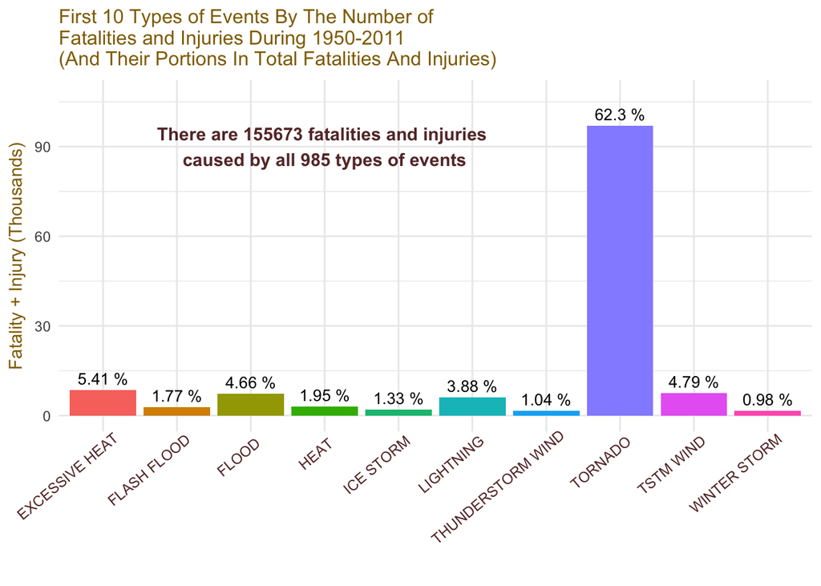

```r
# The plot
library(ggplot2)

div = 1000
ggplot(health_df_total[1:10,], aes(x = EVTYPE, y = FATALITY_INJURY/div, fill = EVTYPE)) +
        geom_bar(stat = "identity") +
        geom_text(aes(label = PERCENT_CHAR), vjust = -0.5, size = 3.5) +
        labs(title = "First 10 Types of Events By The Number of \nFatalities and Injuries During 1950-2011\n(And Their Portions In Total Fatalities And Injuries)") +
        labs(x = "") +
        labs(y = "Fatality + Injury (Thousands)") +
        theme_minimal() +
        theme(legend.position = "none") +
        theme(axis.text.x = element_text(angle = 40, hjust = 0.9, vjust = 1, size = 9, color = rgb(0.4,0.2,0.2))) +
        theme(axis.title.y = element_text(color = colorRampPalette(c("green", "red"))(15)[9])) +
        theme(plot.title = element_text(color = colorRampPalette(c("green", "red"))(15)[9], size = 12)) +
        scale_y_continuous(limits = c(min(health_df_total$FATALITY_INJURY),
                                      max(health_df_total$FATALITY_INJURY)+10000)/div) +
        annotate("text", x = 4, y = 90, color = rgb(0.4,0.2,0.2), fontface = 2,
                 label = paste("There are", as.character(count_fatal_injur),
                               "fatalities and injuries \ncaused by all",
                                as.character(count_event_types), "types of events"))
```

As we would guess Tornado is the first harmful event, Excessive Heat is scaringly the second harmful event, then come Tstm Wind, Flood, Lightning and the rest. We also see that there are many more types of events that are not shown on the plot and among all these 985 types of events Tornado causes a gigentic harm to population health.

Now let’s move on to the second question.

### Across the United States, which types of events have the greatest economic consequences?

To answer this question we will make a single plot with top 10 harmful event types that have the greatest economic consequences. We do it in three steps.

- Creating the initial data frame called **economic_df**
- Processing **economic_df** data frame
- Making the plot

#### Creating the initial data frame called **economic_df**

We need 6 columns (EVTYPE, PROPDMG, PROPDMGEXP, CROPDMG, CROPDMGEXP, REMARKS).

```r
library(dplyr)

economic_df <- storm_data %>%
        select(EVTYPE, PROPDMG, PROPDMGEXP, CROPDMG, CROPDMGEXP, REMARKS)
dim(economic_df)
```

```
## [1] 902297      6
```

```r
head(economic_df, 3)
```

```
##    EVTYPE PROPDMG PROPDMGEXP CROPDMG CROPDMGEXP REMARKS
## 1 TORNADO    25.0          K       0
## 2 TORNADO     2.5          K       0
## 3 TORNADO    25.0          K       0
```

```r
str(economic_df)
```

```
## 'data.frame':    902297 obs. of  6 variables:
##  $ EVTYPE    : Factor w/ 985 levels "   HIGH SURF ADVISORY",..: 834 834 834 834 834 834 834 834 834 834 ...
##  $ PROPDMG   : num  25 2.5 25 2.5 2.5 2.5 2.5 2.5 25 25 ...
##  $ PROPDMGEXP: Factor w/ 19 levels "","-","?","+",..: 17 17 17 17 17 17 17 17 17 17 ...
##  $ CROPDMG   : num  0 0 0 0 0 0 0 0 0 0 ...
##  $ CROPDMGEXP: Factor w/ 9 levels "","?","0","2",..: 1 1 1 1 1 1 1 1 1 1 ...
##  $ REMARKS   : Factor w/ 436781 levels "","\t","\t\t",..: 1 1 1 1 1 1 1 1 1 1 ...
```

#### Processing economic_df data frame

The two columns **PROPDMGEXP** and **CROPDMGEXP** that we have selected are the alphabetical characters signifying the magnitudes of the numbers in **PROPDMG** and **CROPDMG**. “Alphabetical characters used to signify magnitude include **“K”** for thousands, **“M”** for millions, and **“B”** for billions” as explained in section 2.7 of [Storm Data Documentation](https://d396qusza40orc.cloudfront.net/repdata%2Fpeer2_doc%2Fpd01016005curr.pdf). But we notice that in these columns there are other values as well. We need to do something about these other values. Let’s deeg a little bit.

1. **Dealing with 0s**
   1. Make **PROPDMGEXP** and **CROPDMGEXP** from factor to character (also change REMARKS column to character as we will need it later).
   2. We can start simplifying **PROPDMGEXP** by first looking at the values of **PROPDMGEXP** when **PROPDMG** is equal to zero. We create a new data frame **economic_1** that has only rows where **PROPDMG == 0**. **PROPDMGEXP** column of **economic_1** shows what values correspond to the 0s of **PROPDMG**. We definitely need to change these values to be equal to 0.
   3. Wherever **PROPDMG** is 0 in **economic_df** data frame, set the value of **PROPDMGEXP** to 0. Do the same with **CROPDMGEXP** wherever **CROPDMG** is equal to 0.
   4. We now hope that we will have fewer rows to worry about. And we are right. Let’s check how many rows of **PROPDMGEXP** and **CROPDMGEXP** are left that have values other then “K”, “M”, “B”, and “0”.

```r
library(dplyr)

# 1
# 1_a
economic_df$PROPDMGEXP <- as.character(economic_df$PROPDMGEXP)
economic_df$CROPDMGEXP <- as.character(economic_df$CROPDMGEXP)
economic_df$REMARKS <- as.character(economic_df$REMARKS)

# 1_b
economic_1 <- economic_df[economic_df$PROPDMG == 0,]
economic_1 %>% group_by(PROPDMGEXP) %>% summarize(count = length(PROPDMGEXP))
```

```
## # A tibble: 12 x 2
##    PROPDMGEXP  count
##         <chr>  <int>
##  1            465858
##  2          ?      8
##  3          0      7
##  4          1     25
##  5          2     12
##  6          3      3
##  7          5     10
##  8          6      1
##  9          7      3
## 10          8      1
## 11          K 197184
## 12          M     11
```

```r
# 1_c
economic_df <- within(economic_df, PROPDMGEXP[PROPDMG == 0] <- "0")
economic_df <- within(economic_df, CROPDMGEXP[CROPDMG == 0] <- "0")

# 1_d
economic_2 <- economic_df[grep("[^0KMB]", economic_df$PROPDMGEXP),]
economic_3 <- economic_df[grep("[^0KMB]", economic_df$CROPDMGEXP),]
dim(economic_2)
```

```
## [1] 49  6
```

```r
dim(economic_3)
```

```
## [1] 22  6
```

2. **Dealing with non-0s**
   1. First, let’s look at the unique values in **PROPDMGEXP** and **CROPDMGEXP** that are not “K”, “M”, “B” or “0”, and thus need to be changed. We see **11** values of **PROPDMGEXP** and **2** values of **CROPDMGEXP** that need our attention.
   2. **PROPDMGEXP** - Let’s explore “m” as it may indicate million entered in lowercas instead of an uppercase “M”. Then we will look at the rest of the values one by one. We will find **REMARKS** column handy for this task. Also, we can read the **Appendix B** of [Storm Data Documentation](https://d396qusza40orc.cloudfront.net/repdata%2Fpeer2_doc%2Fpd01016005curr.pdf) to get the idea of property damage estimates.
      - **“m”** - By reading the remarks column and Appendix B, we can definitely say that “m” stands for millions. Change “m” of **PROPDMGEXP** with “M” in **economic_df**.
      - **“H” and “h”** - Maybe they stand for hundreds? Again, let’s read remarks. They really seem to stand for hundreds. Change “H” and “h” of **PROPDMGEXP** to “100” in economic_df.
      - To change **“7”**, **“6”**, **“5”**, **“4”**, **“3”**, **“2”**, **“+”**, **“-”** values, we need to do a lot of guessing. So we will dare to ignore these values (hopefully, we will not loose a lot of information as there are only few rows with these values). In other words, we will replace these values with 0s. To do all replacements with one function call we will create a function called **mgsub** (“multiple gsub”“) as done in the post on Stackoveflow ([link to the post on Stackoverflow](https://stackoverflow.com/questions/15253954/replace-multiple-arguments-with-gsub)).
   3. **CROPDMGEXP** - We now look at the values of **CROPDMGEXP** and do the necessary replacements. Again, we use **REMARKS** column. Looks like “m” stands for million and “k” stands for thousand. In case of “k”, **REMARKS** column has many empty entries but from the property damage columns we can guess that it is a damage to the crop in thousands. So we will replace “k” and “m” of **CROPDMGEXP** with “K” and “M” in **economic_df** data frame.
   4. We are almost finished with processing columns **PROPDMGEXP** and **CROPDMGEXP**. Let’s look at the values that each column has and their counts. We see emtpy entries. These empty entries are the last item we are going to worry about. We’ll look at columns **PROPDMG** and **REMARKS** when **PROPDMGEXP** is empty, as well as **CROPDMG** and **REMARKD** when **CROPDMGEXP** is empty. We see that **REMARKS** column has descriptions of damages. So the least we can do is to change these empty entries in **PROPDMGEXP** and **CROPDMGEXP** with “K” to make these damages appear in our analysis. And that may be the exact amount of the damage but we will be careful, anyway, and ignore the rows where no remarks are made. In short, we change empty entries with “K”s when there are remarks and with “0”s when remarks are missing (missing remarks are noted by two spaces: " “).
   5. We will have a final look at the values in **PROPDMGEXP** and **CROPDMGEXP** to make sure we are only left with “K”, “M”, “B”, “0” and “100”. We can now change “K” to “1000”, “M” to “1000000”, “B” to “1000000000” and convert these columns from character to numeric.

```r
library(dplyr)

# 2
# 2_a
unique(economic_2$PROPDMGEXP)
```

```
##  [1] "m" "+" "5" "6" "4" "h" "2" "7" "3" "H" "-"
```

```r
unique(economic_3$CROPDMGEXP)
```

```
## [1] "m" "k"
```

```r
# 2_b
economic_2 %>% group_by(PROPDMGEXP) %>% summarise(count = length(PROPDMGEXP))
```

```
## # A tibble: 11 x 2
##    PROPDMGEXP count
##         <chr> <int>
##  1          -     1
##  2          +     5
##  3          2     1
##  4          3     1
##  5          4     4
##  6          5    18
##  7          6     3
##  8          7     2
##  9          h     1
## 10          H     6
## 11          m     7
```

```r
economic_2[economic_2$PROPDMGEXP == "m",]
```

```
##                    EVTYPE PROPDMG PROPDMGEXP CROPDMG CROPDMGEXP
## 187584     HURRICANE OPAL    20.0          m      10          m
## 195369            TORNADO     0.5          m       0          0
## 196712            TORNADO    10.0          m       0          0
## 202891               HAIL     4.9          m       0          0
## 203087 THUNDERSTORM WINDS     2.0          m       0          0
## 207157 THUNDERSTORM WINDS     0.5          m       0          0
## 211464            TORNADO     1.0          m       0          0
##                                                                                                                                                                                                                                                                                                          …
## 187584 Hurricane Opal moved northward across south Alabama during the evening and early morning hours. Widespread minor damage occurred to homes and other structures with sporadic occurrences of more serious damage. Trees, many large, were downed causing damage to vehicles, buildings, as well as …
## 195369                                                                                                                                                                                                                                                                                                   …
## 196712                                                                                                                             A tornado first touched down on the north side of the Albany Dougherty County Airport then moved east north-east for five miles to just past U.S. Highway 19.  In two …
## 202891                                                                                                                                                                                                                                                                                                   …
## 203087                                                                                                                                                                                                                                                                                                   …
## 207157                                                                                                                                                                                                                                                                                                   …
## 211464                                                                                                                                                                                                                                                                                                   …
```

```r
economic_2[economic_2$PROPDMGEXP == "H",]
```

```
##                    EVTYPE PROPDMG PROPDMGEXP CROPDMG CROPDMGEXP
## 216476 THUNDERSTORM WINDS       5          H       0          0
## 232397 THUNDERSTORM WINDS       5          H       0          0
## 232398 THUNDERSTORM WINDS       2          H       0          0
## 232735 THUNDERSTORM WINDS       3          H       0          0
## 248019 THUNDERSTORM WINDS       5          H       0          0
## 248038               HAIL       5          H       0          0
##                                                                                                                                                                                                                                                                                                          …
## 216476                                                                                                                                                                                                                                                                                                   …
## 232397                                                                                                                                                                                                                                                                                                   …
## 232398 A strong cold front moving through the area generated high winds in the mountainous section of Greenville County downing a number of trees and power lines.  Power remained out until the next morning in some areas.  A line of thunderstorms developed along the front.  A very small tornado (p…
## 232735
## 248019                                                                                                                                                                                                                                                                                                   …
## 248038                                                                                                                                                                                                                                                                                                   …
```

```r
economic_2[economic_2$PROPDMGEXP == "H",]$REMARKS
```

```
## [1] "Thunderstorm winds downed a tree in Loomis and blew down large tree limbs at Hazard.  Just west of Loomis, thunderstorm winds damaged a grain bin, a barn and another outbuilding and also flipped over a hay trailer.  Heavy rain and small hail combined with the wind to damage the corn crop. "
## [2] "A line of severe thunderstorms with a \"bow echo\" appearance moved swiftly through the Upstate during the morning hours.  Highest winds with the bow were around the Georgia border in Oconee County and one small tornado was generated west of Fair Play.  Large trees were uprooted and pines we…
## [3] "A strong cold front moving through the area generated high winds in the mountainous section of Greenville County downing a number of trees and power lines.  Power remained out until the next morning in some areas.  A line of thunderstorms developed along the front.  A very small tornado (pos…
## [4] "  "
## [5] "Strong thunderstorm winds knocked down a tree, many tree limbs and a flagpole in Greybull.  One and three quarter inch diameter hail fell in Greybull. "
## [6] "One inch diameter hail fell in Recluse and in Gillette.  The hail damaged trees and gardens in Gillette.  One outdoor booth at a rodeo in Gillette was demolished and some trailers were damaged.  At the same rodeo, 2 people sustained minor injuries due to the hail.  The hail was in drifts 6 t…
```

```r
economic_2[economic_2$PROPDMGEXP == "h",]
```

```
##                       EVTYPE PROPDMG PROPDMGEXP CROPDMG CROPDMGEXP
## 209285 THUNDERSTORM WIND G50       2          h       0          0
##                                                                                                      REMARKS
## 209285 Wind damage reported at Parks Rd. and U.S. Highway 27.  Trees downed and window of a home blown out.
```

```r
economic_df$PROPDMGEXP <- gsub("m", "M", economic_df$PROPDMGEXP)
economic_df$PROPDMGEXP <- gsub("H", "100", economic_df$PROPDMGEXP)
economic_df$PROPDMGEXP <- gsub("h", "100", economic_df$PROPDMGEXP)

mgsub <- function(pattern, replacement, x, ...) {
  if (length(pattern)!=length(replacement)) {
    stop("pattern and replacement do not have the same length.")
  }
  result <- x
  for (i in 1:length(pattern)) {
    result <- gsub(pattern[i], replacement[i], result, ...)
  }
  result
}

economic_df$PROPDMGEXP <- mgsub(c("2", "3", "4", "5", "6", "7", "\\+", "\\-"),
                                c("0", "0", "0", "0", "0", "0", "0", "0"),
                                economic_df$PROPDMGEXP)

# 2_c
economic_3[economic_3$CROPDMGEXP == "m",]
```

```
##                EVTYPE PROPDMG PROPDMGEXP CROPDMG CROPDMGEXP
## 187584 HURRICANE OPAL      20          m      10          m
##                                                                                                                                                                                                                                                                                                          …
## 187584 Hurricane Opal moved northward across south Alabama during the evening and early morning hours. Widespread minor damage occurred to homes and other structures with sporadic occurrences of more serious damage. Trees, many large, were downed causing damage to vehicles, buildings, as well as …
```

```r
economic_3[economic_3$CROPDMGEXP == "k",]
```

```
##                    EVTYPE PROPDMG PROPDMGEXP CROPDMG CROPDMGEXP
## 195667     FLASH FLOODING       2          K      10          k
## 200542 THUNDERSTORM WINDS      50          K       1          k
## 200543 THUNDERSTORM WINDS      50          K       1          k
## 200618               HAIL       2          K       1          k
## 200632               HAIL       1          K       3          k
## 200880               HAIL       3          K       3          k
## 200881               HAIL       3          K       1          k
## 200882               HAIL      20          K      15          k
## 200883               HAIL      10          K      15          k
## 200884               HAIL       3          K       1          k
## 201144               HAIL       3          K       1          k
## 201145 THUNDERSTORM WINDS       5          K       1          k
## 201674               HAIL       3          K       1          k
## 201675               HAIL      50          K      10          k
## 201676               HAIL       3          K       1          k
## 201677               HAIL      20          K       5          k
## 201977               HAIL      15          K       5          k
## 201978               HAIL      10          K       5          k
## 202101 THUNDERSTORM WINDS      25          K       1          k
## 202257               HAIL      50          K     350          k
## 202262        WIND DAMAGE      10          K       5          k
##                                                                                                                                                                                                                      REMARKS
## 195667 Fifteen roads in the north part of the county, generally north of Interstate 10, were closed due to high water.  Highway 85, north of Interstate 10, had a foot of water in it and had to be closed for a few hours.
## 200542
## 200543
## 200618
## 200632
## 200880
## 200881
## 200882
## 200883
## 200884
## 201144
## 201145
## 201674
## 201675
## 201676
## 201677
## 201977
## 201978
## 202101
## 202257
## 202262                                                                                                                                                                    Trees and power lines down, some damage to homes.
```

```r
economic_df$CROPDMGEXP <- gsub("m", "M", economic_df$CROPDMGEXP)
economic_df$CROPDMGEXP <- gsub("k", "K", economic_df$CROPDMGEXP)

# 2_d
economic_df %>% group_by(PROPDMGEXP) %>% summarize(count = length(PROPDMGEXP))
```

```
## # A tibble: 6 x 2
##   PROPDMGEXP  count
##        <chr>  <int>
## 1                76
## 2          0 663367
## 3        100      7
## 4          B     40
## 5          K 227481
## 6          M  11326
```

```r
economic_df %>% group_by(CROPDMGEXP) %>% summarize(count = length(CROPDMGEXP))
```

```
## # A tibble: 5 x 2
##   CROPDMGEXP  count
##        <chr>  <int>
## 1                 3
## 2          0 880210
## 3          B      7
## 4          K  20158
## 5          M   1919
```

```r
cbind(economic_df[economic_df$PROPDMGEXP == "",]$PROPDMG,
      economic_df[economic_df$PROPDMGEXP == "",]$REMARKS)
```

```
##       [,1]
##  [1,] "0.41"
##  [2,] "3"
##  [3,] "2"
##  [4,] "4"
##  [5,] "4"
##  [6,] "10"
##  [7,] "10"
##  [8,] "10"
##  [9,] "4"
## [10,] "5"
## [11,] "10"
## [12,] "35"
## [13,] "75"
## [14,] "3"
```

[output cut: 139 more lines]

```r
cbind(economic_df[economic_df$CROPDMGEXP == "",]$CROPDMG,
      economic_df[economic_df$CROPDMGEXP == "",]$REMARKS)
```

```
##      [,1]
## [1,] "3"
## [2,] "4"
## [3,] "4"
##      [,2]
## [1,] "  "
## [2,] "Thunderstorms produced widespread large hail, accompanied by damaging winds that knocked down tree limbs, stripped leaves from trees and knocked out power and telephone communications to San Marcos for several hours.  The hailstones broke windows in homes and school as well as Southwest Sta…
## [3,] "Thunderstorms moving eastward through Medina County produced widespread wind damage.  The Red Cross reported that 32 homes were destroyed, 44 had major damage, and 194 homes had minor damage.  Numerous mobile homes suffered roof and wall damage.  The city of Castroville was without power fr…
```

```r
economic_df <- within(economic_df,
                      PROPDMGEXP[PROPDMGEXP == ""][REMARKS[PROPDMGEXP == ""] == "  "] <- "0")
economic_df <- within(economic_df,
                      CROPDMGEXP[CROPDMGEXP == ""][REMARKS[CROPDMGEXP == ""] == "  "] <- "0")

economic_df <- within(economic_df,
                      PROPDMGEXP[PROPDMGEXP == ""][REMARKS[PROPDMGEXP == ""] != "  "] <- "K")
economic_df <- within(economic_df,
                      CROPDMGEXP[CROPDMGEXP == ""][REMARKS[CROPDMGEXP == ""] != "  "] <- "K")

# 2_e
economic_df %>% group_by(PROPDMGEXP) %>% summarize(count = length(PROPDMGEXP))
```

```
## # A tibble: 5 x 2
##   PROPDMGEXP  count
##        <chr>  <int>
## 1          0 663381
## 2        100      7
## 3          B     40
## 4          K 227543
## 5          M  11326
```

```r
economic_df %>% group_by(CROPDMGEXP) %>% summarize(count = length(CROPDMGEXP))
```

```
## # A tibble: 4 x 2
##   CROPDMGEXP  count
##        <chr>  <int>
## 1          0 880211
## 2          B      7
## 3          K  20160
## 4          M   1919
```

```r
economic_df$PROPDMGEXP <- as.numeric(mgsub(c("K", "M", "B"),
                                c("1000", "1000000", "1000000000"),
                                economic_df$PROPDMGEXP))
economic_df$CROPDMGEXP <- as.numeric(mgsub(c("K", "M", "B"),
                                c("1000", "1000000", "1000000000"),
                                economic_df$CROPDMGEXP))
```

#### Making the plot

1. Create a new data frame called **economic_plot_df** which will have combined **PROPDMG** and **CROPDMG** columns (first we will multiply **PROPDMG** with **PROPDMGEXP** and **CROPDMG** with **CROPDMGEXP**.
2. Count total number of event types and total number of damage to property and crop.
3. Create **PERCENT** and **PERCENT_CHAR** columns to make our plot more informative.
4. Make the plot

```r
library(dplyr)

# 1
economic_plot_df <- economic_df %>%
        group_by(EVTYPE) %>%
        summarise(PROP = sum(PROPDMG * PROPDMGEXP), CROP = sum(CROPDMG * CROPDMGEXP)) %>%
        mutate(PROP_CROP_DMG = PROP + CROP) %>%
        arrange(desc(PROP_CROP_DMG))
dim(economic_plot_df)
```

```
## [1] 985   4
```

```r
head(economic_plot_df, 3)
```

```
## # A tibble: 3 x 4
##              EVTYPE         PROP       CROP PROP_CROP_DMG
##              <fctr>        <dbl>      <dbl>         <dbl>
## 1             FLOOD 144657716800 5661968450  150319685250
## 2 HURRICANE/TYPHOON  69305840000 2607872800   71913712800
## 3           TORNADO  56937163480  414953110   57352116590
```

```r
# 2
count_event_types <- nrow(economic_plot_df)
sum_prop_crop <- sum(economic_plot_df$PROP_CROP_DMG)

# 3
economic_plot_df <- economic_plot_df %>%
        mutate(PERCENT = PROP_CROP_DMG * 100/sum_prop_crop) %>%
        mutate(PERCENT_CHAR = paste(as.character(round(PERCENT, digits = 2)),"%"))
dim(economic_plot_df)
```

```
## [1] 985   6
```

```r
head(economic_plot_df, 3)
```

```
## # A tibble: 3 x 6
##              EVTYPE         PROP       CROP PROP_CROP_DMG  PERCENT
##              <fctr>        <dbl>      <dbl>         <dbl>    <dbl>
## 1             FLOOD 144657716800 5661968450  150319685250 31.55171
## 2 HURRICANE/TYPHOON  69305840000 2607872800   71913712800 15.09450
## 3           TORNADO  56937163480  414953110   57352116590 12.03806
## # ... with 1 more variables: PERCENT_CHAR <chr>
```

And we can make our plot.

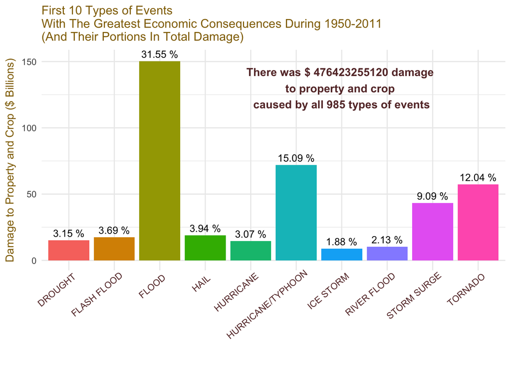

```r
library(ggplot2)

# 4 plot
div = 1000000000
ggplot(economic_plot_df[1:10,], aes(x = EVTYPE, y = PROP_CROP_DMG/div, fill = EVTYPE)) +
        geom_bar(stat = "identity") +
        geom_text(aes(label = PERCENT_CHAR), vjust = -0.5, size = 3.5) +
        labs(title = "First 10 Types of Events\nWith The Greatest Economic Consequences During 1950-2011\n(And Their Portions In Total Damage)") +
        labs(x = "") +
        labs(y = "Damage to Property and Crop ($ Billions)") +
        theme_minimal() +
        theme(legend.position = "none") +
        theme(axis.text.x = element_text(angle = 40, hjust = 0.9, vjust = 1, size = 9, color = rgb(0.4,0.2,0.2))) +
        theme(axis.title.y = element_text(color = colorRampPalette(c("green", "red"))(15)[9])) +
        theme(plot.title = element_text(color = colorRampPalette(c("green", "red"))(15)[9], size = 12)) +
        scale_y_continuous(limits = c(min(economic_plot_df$PROP_CROP_DMG),
                                      max(economic_plot_df$PROP_CROP_DMG)+1000000000)/div) +
        annotate("text", x = 7, y = 130, color = rgb(0.4,0.2,0.2), fontface = 2,
                 label = paste("There was $", as.character(sum_prop_crop),
                               "damage \nto property and crop \ncaused by all",
                                as.character(count_event_types), "types of events"))
```

From the plot above we see that Flood had the greates economic consequences across the United States from 1950 to 2011. Then come Hurricane/Typhoon, Tornado, Storm Surge, and the rest.